# HW6 - Neural Network by `tf.keras`

##### 負責助教：張逸群 toosyou.tw@gmail.com

> 本次作業將使用 **Fashion-MNIST** 時尚資料集並以 `tf.keras` 設計 Neural Network 以進行衣物、鞋子及包包的辨識

## [資料簡介](https://github.com/zalandoresearch/fashion-mnist)

Fashion-MNIST is a dataset of Zalando's article images—consisting of a training set of 60,000 examples and a test set of 10,000 examples.  
Each example is a 28x28 grayscale image, associated with a label from 10 classes.  
We intend Fashion-MNIST to serve as a direct drop-in replacement for the original MNIST dataset for benchmarking machine learning algorithms.  
It shares the same image size and structure of training and testing splits.

#### 學號：109705002

## Packages that Might Be Used

```python
import matplotlib.pyplot as plt
import tensorflow as tf
from tensorflow.keras.utils import to_categorical
from tensorflow.keras.datasets.fashion_mnist import load_data
import numpy as np

from sklearn.metrics import classification_report

%matplotlib inline
```

### 相關連結

- Packages
  - [numpy](http://www.numpy.org/)
  - [pandas](https://pandas.pydata.org/)
  - [train_test_split](https://scikit-learn.org/stable/modules/generated/sklearn.model_selection.train_test_split.html)
  - [pyplot](https://matplotlib.org/tutorials/introductory/pyplot.html)
  - [tf.keras](https://www.tensorflow.org/api_docs/python/tf/keras)
  - [tf.keras.datasets.fashion_mnist.load_data](https://www.tensorflow.org/api_docs/python/tf/keras/datasets/fashion_mnist/load_data)
  - [tf.keras.utils.to_categorical](https://www.tensorflow.org/api_docs/python/tf/keras/utils/to_categorical)
  - [sklearn.metrics.classification_report](https://scikit-learn.org/stable/modules/generated/sklearn.metrics.classification_report.html)
- Markdown
  - jupyter 可以支援 markdown 區塊，方便打上文字說明此份 notebook 在做的事情
  - [wiki](https://zh.wikipedia.org/wiki/Markdown)
  - [教學](https://markdown.tw/)

## Load Data - 5%

#### 請使用 `tf.keras.datasets.fashion_mnist` 中提供的 `load_data` 函式讀取資料 - 5%

```python
(X_train, y_train), (X_test, y_test) = tf.keras.datasets.fashion_mnist.load_data()

X_train.shape, y_train.shape, X_test.shape, y_test.shape
```

```
((60000, 28, 28), (60000,), (10000, 28, 28), (10000,))
```

> 由此可見 `fashion_mnist.load_data` 已將 training set 與 testing set 分好了，  
> 一般是為了使各研究可以有一致的分割，因此這做法在公開資料集中非常常見

## Data Visualization - 25%

#### 請將 `X_train` 中的前二十五筆資料，使用 `plt.subplots` 以 $5\times5$ 排列畫製 - 10%

- [Hint](https://matplotlib.org/stable/gallery/subplots_axes_and_figures/subplot_toolbar.html#sphx-glr-gallery-subplots-axes-and-figures-subplot-toolbar-py)

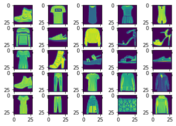

```python
fig, axs = plt.subplots(5, 5)
t = 0
for i in range(5):
    for j in range(5):
        axs[i, j].imshow(X_train[t])
        t = t+1

plt.show()
```

#### 請回答以下問題 - 5%

1. 請問上方的圖，紫色的部分（背景）其數值為何？
   - 0

#### 請將 `X_train` 依照分類（`y_train`）分開，並將各分類取平均並繪製成 $2\times5$ 的圖 - 10%

- 假設某分類 $X$ 具有 $N$ 筆資料，第 $i$ 筆資料為 $X_i$，其中 $$ X_i = [ X_{i, 0, 0}, X_{i, 0, 1}, \cdot X_{i, 28, 28} ]^T $$
- 該分類的平均 $\overline{X}$ 便為 $$ \overline{X} = [ \overline{X_{0, 0}}, \overline{X_{0, 1}}, \cdot \overline{X_{28, 28}} ]^T $$ where, $$ \overline{X_{a, b}} = \frac{\sum^{N-1}_{i=0}{X_{i, a, b}}}{N}, \\ \text{for }0 \le a, b \le 27 $$
- [Hint](https://numpy.org/doc/stable/reference/generated/numpy.mean.html)

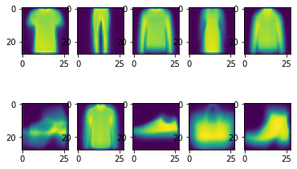

```python
s = np.random.random((10,28,28))
for i in range(10):
  L = []
  for j in range(60000):
    if (i==y_train[j]):
      L.append(j)
  a = len(L)
  ga = np.random.random((a,28,28))
  for k in range(len(L)):
    ga[k] = X_train[L[k],:,:]
  Ga = np.mean(ga,0)
  s[i] = Ga[:,:]


fig, axs = plt.subplots(2,5)
for x in range(2):
  for y in range(5):
    axs[x,y].imshow(np.reshape(s[5*x+y,:],(28,28)))
    y = y+1
  x = x+1
plt.show()
```

## Preprocessing - 20%

#### 請將 `X_train` reshape 成 `(60000, 784)` 並將 `X_test` reshape 成 `10000, 784` - 5%

- 此步是為了符合後面 Neural Network 的 input 格式

```python
X_train = X_train.reshape(60000, 784)
X_test  = X_test.reshape(10000, 784)

X_train.shape, y_train.shape, X_test.shape, y_test.shape
```

```
((60000, 784), (60000,), (10000, 784), (10000,))
```

#### 請使用 `tensorflow.keras.utils.to_categorical` 將 `y_train` 及 `y_test` 轉換成 [**one-hot**](https://zh.wikipedia.org/wiki/One-hot) 形式 - 5%

```python
yy_test = y_test
y_train = tf.keras.utils.to_categorical(y_train)
y_test  = tf.keras.utils.to_categorical(y_test)

y_train.shape, y_test.shape
```

```
((60000, 10), (10000, 10))
```

```python
y_train[:5]
```

```
array([[0., 0., 0., 0., 0., 0., 0., 0., 0., 1.],
       [1., 0., 0., 0., 0., 0., 0., 0., 0., 0.],
       [1., 0., 0., 0., 0., 0., 0., 0., 0., 0.],
       [0., 0., 0., 1., 0., 0., 0., 0., 0., 0.],
       [1., 0., 0., 0., 0., 0., 0., 0., 0., 0.]], dtype=float32)
```

#### 請回答以下問題 - 10%

1. 請問什麼是 one-hot 格式？
   - 僅有一個位元是1，其他皆為0的格式

## Model Construction - 25%

#### 請建造一個 [Multilayer Perceptron (MLP)](https://zh.wikipedia.org/zh-tw/%E5%A4%9A%E5%B1%82%E6%84%9F%E7%9F%A5%E5%99%A8)，並符合以下規格 - 5%

- [請使用 `tf.keras.Sequential` 進行 model 定義](https://tf.wiki/en/basic/models.html#use-keras-sequential-functional-api-to-build-models)
- 該 model 總共具有 $4$ 層 (layer)
  1. Input ，並設定 shape 為 `(784, )`
  2. Dense ，任意設定 `units` 數量，並設定 `activation` 為 `relu`
  3. Dense ，任意設定 `units` 數量，並設定 `activation` 為 `relu`
  4. Dense 作為 output layer，設定 `unit` 為 output shape 的 `10`，並設定 `activation` 為 `softmax`

```python
model = tf.keras.models.Sequential([
            tf.keras.Input(shape=(784, )),
            tf.keras.layers.Dense(50, activation='relu'),
            tf.keras.layers.Dense(50, activation='relu'),
            tf.keras.layers.Dense(10, activation='softmax')
        ])
```

```
WARNING:tensorflow:Please add `keras.layers.InputLayer` instead of `keras.Input` to Sequential model. `keras.Input` is intended to be used by Functional model.
```

#### 請對 `model` 進行 [`compile`](https://www.tensorflow.org/api_docs/python/tf/keras/Model#compile) - 5%

- 設定 `loss` 為 `CategoricalCrossentropy`
- 設定 `metrics` 為 `['acc']`

```python
model.compile(loss='CategoricalCrossentropy',metrics=['acc'])
model.summary() # print out the model
```

```
Model: "sequential"
_________________________________________________________________
Layer (type)                 Output Shape              Param #
=================================================================
dense (Dense)                (None, 50)                39250
_________________________________________________________________
dense_1 (Dense)              (None, 50)                2550
_________________________________________________________________
dense_2 (Dense)              (None, 10)                510
=================================================================
Total params: 42,310
Trainable params: 42,310
Non-trainable params: 0
_________________________________________________________________
```

#### 請使用 `X_train` 及 `y_train` 對 `model` 進行訓練 - 5%

- [Hint](https://www.tensorflow.org/api_docs/python/tf/keras/Model#fit)
- 請調整 `batch_size` 及 `epochs`
- 設定 `validation_split` 為 0.1

```python
model.fit(x=X_train,y=y_train,batch_size=32,epochs=10,validation_split=0.1)
```

```
<tensorflow.python.keras.callbacks.History at 0x1543152b9e8>
```

## Evaluation - 5%

#### 請使用 `classification_report` 對 testing set 進行 evaluation - 5%

- 注意 `model` 的預測將會是十個數字（對應各個分類的機率），請以其中最大值的分類作為預測
- `y_test` 已是 **one-hot** 形式，須自行進行轉換

```python
prediction = model.predict_classes(X_test)
print(classification_report(yy_test,prediction))
```

```
              precision    recall  f1-score   support

           0       0.73      0.84      0.78      1000
           1       0.98      0.94      0.96      1000
           2       0.30      0.93      0.45      1000
           3       0.97      0.43      0.60      1000
           4       0.00      0.00      0.00      1000
           5       0.96      0.92      0.94      1000
           6       0.27      0.10      0.15      1000
           7       0.94      0.92      0.93      1000
           8       0.96      0.90      0.93      1000
           9       0.92      0.96      0.94      1000

    accuracy                           0.69     10000
   macro avg       0.70      0.69      0.67     10000
weighted avg       0.70      0.69      0.67     10000
```

## Prediction - 20%

#### 請使用圖片編輯器（如 [photopea](http://photopea.com/)），修改一商品的圖片以符合 model 需求，對其進行預測 - 10%

[figure not shown]

```python
import matplotlib.image as mpimg
img = mpimg.imread('images.jpg' )
img = rgb2gray(img)
plt.imshow(img)
plt.show()

img = np.array(img)
img = img.reshape(1,784)
```

```python
prediction1 = model.predict(img)
print(np.array(prediction1))
```

```
[[1.2063553e-01 0.0000000e+00 5.0208746e-05 1.1535249e-02 5.7597251e-08
  7.0374165e-16 8.4950620e-01 8.2526494e-18 1.8272672e-02 0.0000000e+00]]
```

#### 請回答以下問題 - 10%

1. 請問預測是否正確？
   - 否
2. 你覺得是為什麼？
   - 數字不對

## 有什麼想對助教說的嗎？

```python
ANN好難 哭阿
```

### Gura 敲鼓讓他跑快一點

[figure not shown]